# Copy the Masters

Author

Tyler Stoen

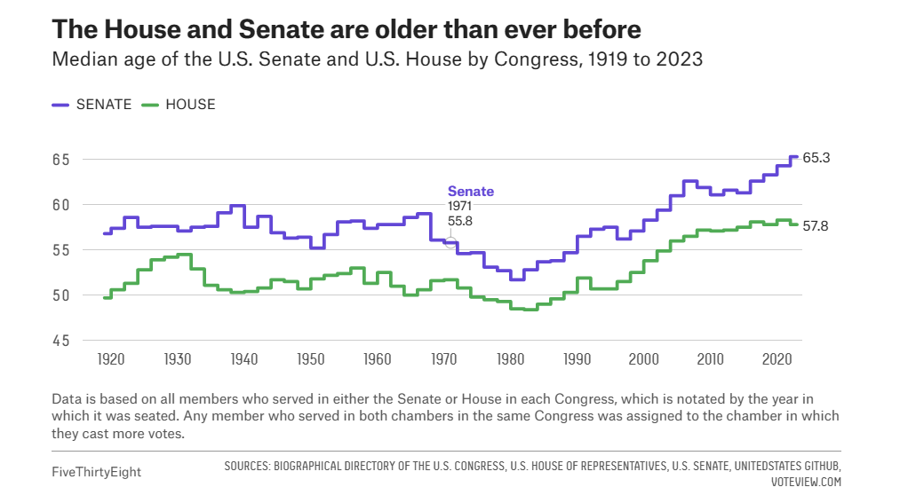

```r
age <- read.csv("C:/Users/Tyler/OneDrive/Desktop/Stat 365/data_aging_congress.csv")
head(age)
```

```
  congress start_date chamber state_abbrev party_code                 bioname
1       82 1951-01-03   House           ND        200    AANDAHL, Fred George
2       80 1947-01-03   House           VA        100 ABBITT, Watkins Moorman
3       81 1949-01-03   House           VA        100 ABBITT, Watkins Moorman
4       82 1951-01-03   House           VA        100 ABBITT, Watkins Moorman
5       83 1953-01-03   House           VA        100 ABBITT, Watkins Moorman
6       84 1955-01-03   House           VA        100 ABBITT, Watkins Moorman
  bioguide_id   birthday cmltv_cong cmltv_chamber age_days age_years generation
1     A000001 1897-04-09          1             1    19626  53.73306       Lost
2     A000002 1908-05-21          1             1    14106  38.62012   Greatest
3     A000002 1908-05-21          2             2    14837  40.62149   Greatest
4     A000002 1908-05-21          3             3    15567  42.62012   Greatest
5     A000002 1908-05-21          4             4    16298  44.62149   Greatest
6     A000002 1908-05-21          5             5    17028  46.62012   Greatest
```

1. Clean Data
2. Group by Chamber
3. Get average age for each start date
4. Plot the average age over time of each chamber using ggplot
5. Change the aesthetics to match the professional graph on fivethirtyeight

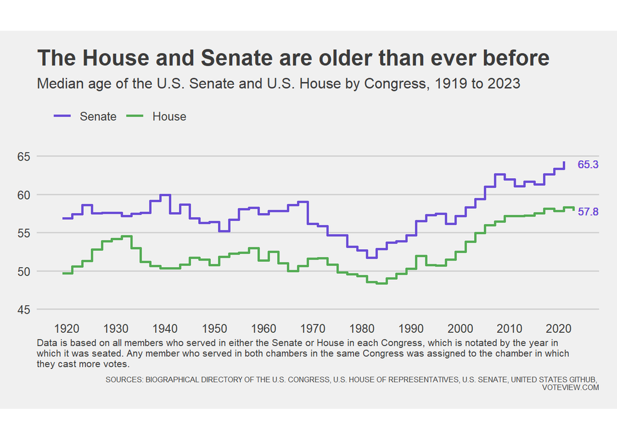

```r
age |>
  group_by(chamber, start_date) |>
  summarize(med_age = median(age_years)) |>
  mutate(date = as.Date(start_date, "%Y-%m-%d"))|>
  ggplot(mapping=aes(x = date, y = med_age)) +
  geom_step(aes(color = fct_relevel(chamber, c("Senate", "House"))),size=1) +
  scale_x_date(breaks = c(mdy("01-01-1920"),
                          mdy("01-01-1930"),
                          mdy("01-01-1940"),
                          mdy("01-01-1950"),
                          mdy("01-01-1960"),
                          mdy("01-01-1970"),
                          mdy("01-01-1980"),
                          mdy("01-01-1990"),
                          mdy("01-01-2000"),
                          mdy("01-01-2010"),
                          mdy("01-01-2020")), date_labels = "%Y") +
  scale_color_manual(name = "", values = c("#6A4CD6", "#54AC54")) +
  labs(title = "The House and Senate are older than ever before",
       subtitle = "Median age of the U.S. Senate and U.S. House by Congress, 1919 to 2023",
       x = "Data is based on all members who served in either the Senate or House in each Congress, which is notated by the year in \nwhich it was seated. Any member who served in both chambers in the same Congress was assigned to the chamber in which \nthey cast more votes.",
       y = "",
       caption = "SOURCES: BIOGRAPHICAL DIRECTORY OF THE U.S. CONGRESS, U.S. HOUSE OF REPRESENTATIVES, U.S. SENATE, UNITED STATES GITHUB, \n VOTEVIEW.COM") +
  geom_text(aes(x = date, y = med_age,
                color = fct_relevel(chamber, c("Senate", "House"))), x = as.Date("2026-01-01"), y = 64, label = "65.3", size = 3, show.legend = F) +
  geom_text(aes(x = date, y = med_age,
                color = fct_relevel(chamber, c("Senate", "House"))), x = as.Date("2026-01-01"), y = 57.8, label = "57.8", size = 3, show.legend = F) +
  theme_fivethirtyeight() +
  ylim(45, 65) +
  theme(aspect.ratio = 0.3,legend.position = "top", legend.justification = "left",
        plot.caption = element_text(size = 6),
        axis.title.x = element_text(hjust = 0, size = 8),
        panel.grid.major.x = element_blank())
```

The graphic shows the median age of the Senate compared to the House of Representatives over time starting in 1919. The purpose of the graph is to showcase that the current median age of both chambers is the oldest it has ever been, as described in the title of the graph. The current median age in the Senate is about 65 while the median age in the House of Representatives is about 58. In the article posted on fivethirtyeight, it mentions that this may be a concern, as older politicians tend to be relatively unfamiliar with modern technology.

In my opinion, the graph does a good job showing that, in recent years, the median age of both chambers has been the oldest, at least in the range of the data. By quickly glancing at the graph, it is clear that the highest point in the graph is further to the right (more recent). Although I would likely not choose to use a step graph for this visualization, it works well as you are able to see which parts of the graph represent a new term. The addition of the label for the median age of the most recent year is also a nice touch to make it more clear how old the chambers have really become. Also, the graph does a good job citing sources and even includes what was done when a member served in both chambers. In my opinion, the text under the graph is a bit lengthy and including that elsewhere, such as in the article itself, may have been a better choice to reduce the amount of visual clutter in the graph. The y-axis label was also changed into a “subtitle” to make it easier to read. The titles is descriptive and gives the reader insight on what to expect in the graph.